# Pokemon Unit 3 Project

To start off, I first created a linear regression model and examined it’s summary of statistics. There I was provided the residuals, coefficients, slope, intercept, standard errors, t values, p-value for t-test, significance codes, residual standard error, and r-squared. With this information, I created a residuals vs fitted plot to examine the linearity of the data. In the plot, there is a somewhat distributed scatter. With that in mind, there also wasn’t any noticeable pronounced pattern so we can assume that there is an indication for a linear relationship. Some clumping can also be seen on the left side of the residuals vs fitted plot, but we can assume that the linear assumption is met.

For the Independence condition, looking back on the residuals versus fits scatter plot, there was a somewhat distributed scatter of points. We can assume that the residuals are independent because the graph doesn’t appear like there is a relationship or pattern of some sort.

Lastly, for the Normality condition, I created a Normal Q-Q plot and histogram plot to check the normality of residuals. In the Normal Q-Q plot, most of the points fall close to the line, however there is a slight curving at the end heading upwards. The points at the start of the line, where the theoretical quantities are -3 and 3, slightly stand out from the rest of the data points in the middle. As for the histogram plot, the residuals appear to be slightly right skewed, thus indicating it isn’t normally distributed. With this information, we can assume that all conditions are valid except for normality.

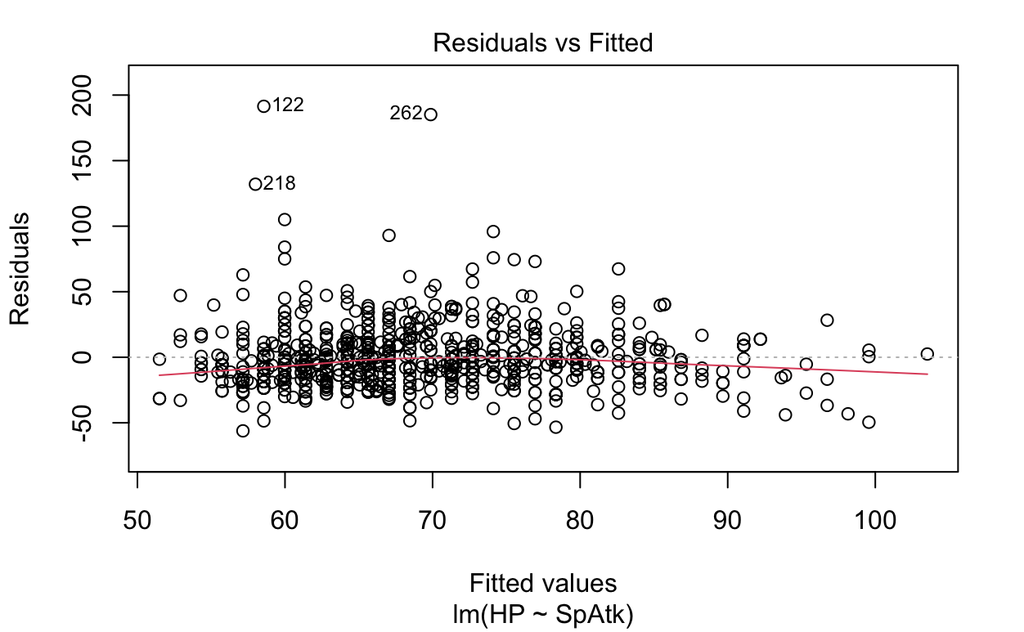

```r
#Model Diagnostics
#Check linearity of the data by creating Residuals vs Fitted plot
plot(regmodel, 1)
```

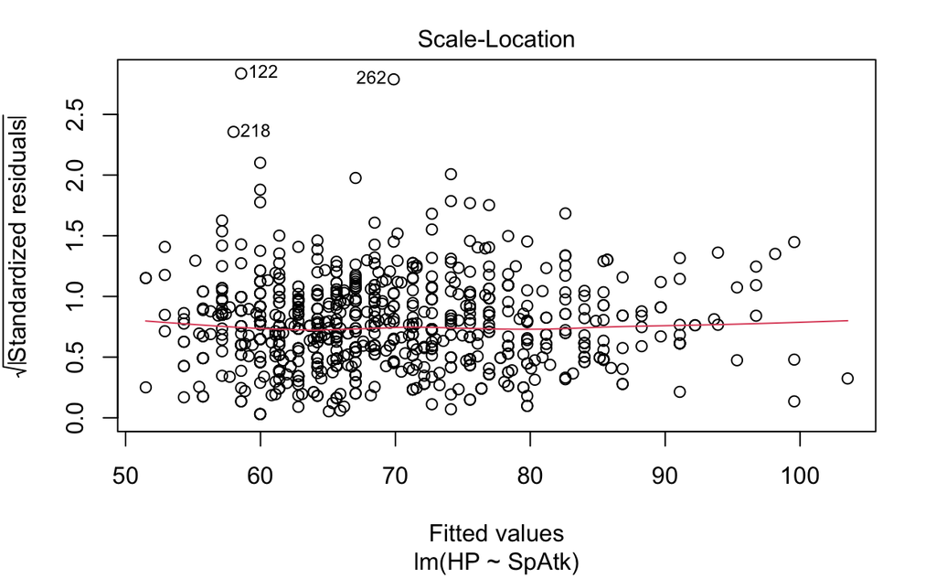

```r
#Check Homogeneity of Variance
plot(regmodel, 3)
```

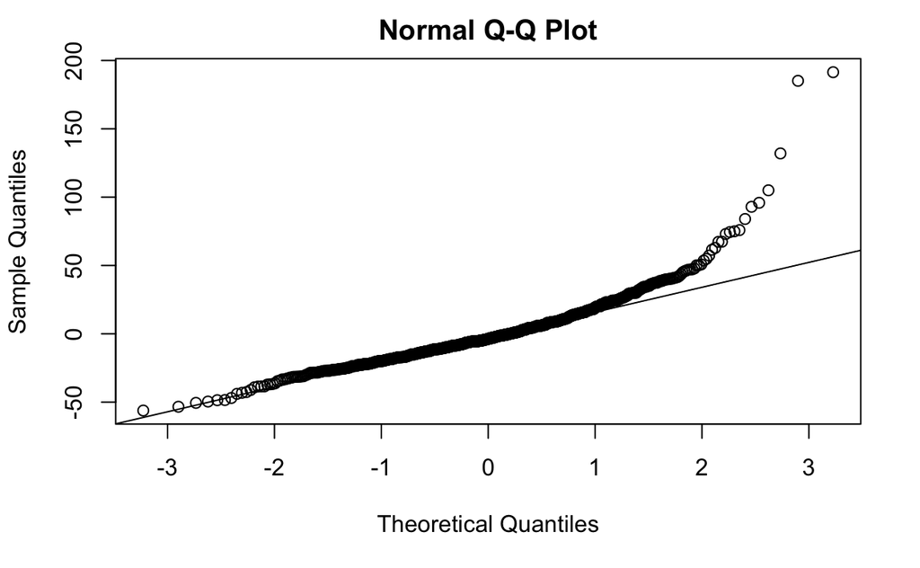

```r
#Creating Normal Q-Q plot to check Normality of Residuals
qqnorm(regmodel$residuals)
qqline(regmodel$residuals)
```

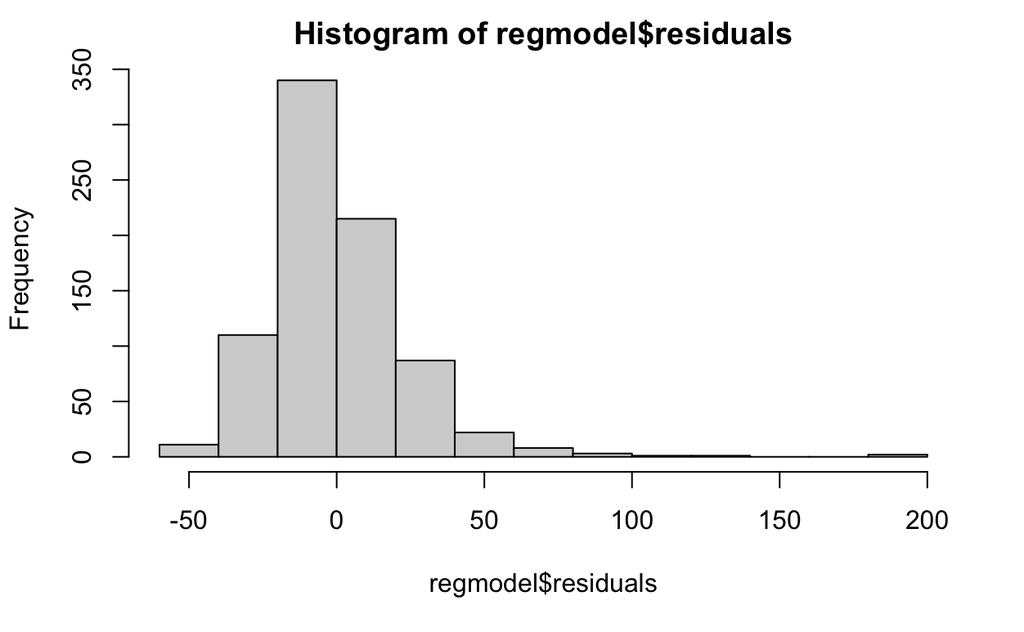

```r
#Creating Histogram plot to check Normality of Residuals
hist(regmodel$residuals)
```

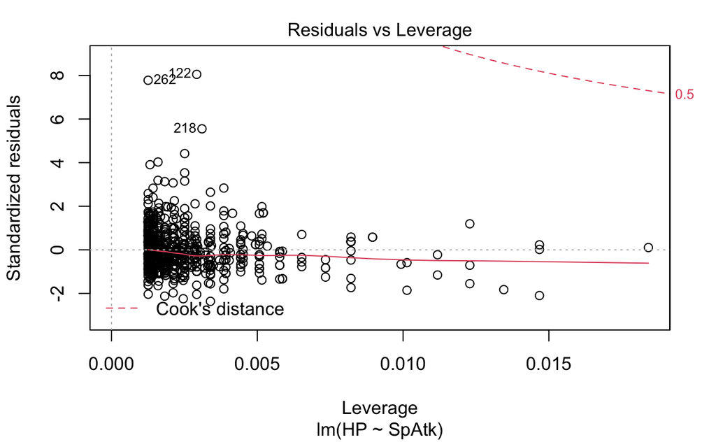

```r
#Creating a plot identifying outliers and high leverage points (also showing top 3 extreme points)
plot(regmodel, 5)
```

In terms of the goodness of fit for the linear regression model, the R-squared value is 0.1313192. The regression model consists of a low R-squared value (13.1% out of 100%). Essentially, this means that the model lacks thorough explanation of the variation in the response variable (HP) around its mean and that the scatter of the data points around the fitted regression line has a somewhat large difference between the observed data and fitted values.

Furthermore, there are a couple limitations that need to be addressed. Due to the linear regression line not meeting all of the conditions (unable to meet normality), this is a limitation that suggests for me to transform the data or find a more appropriate distribution with different variables. There are also noticeable extreme points (262, 218, and 122) and outliers within the data after plotting a residuals vs leverage plot. A couple outliers fall on the right side of the graph, thus making the data skewed to the right and most likely affecting the slope of the regression line.

Overall, the two quantitative variables I analyzed, HP being the response variable and SpAtk being the explanatory variable, can be assumed that there is an association. Various plots and diagnostics were used to determine whether or not the linear regression of HP and SpAtk have met the linear model conditions. After the conditions were examined, I was able to determine the null and alternative hypotheses, analyze further on the statistics of the regression, specifically t-values and p-values, and conclude on an associating relationship between Pokemon HP and SpAtk.

```r
#Finding the R squared
summary(regmodel)$r.squared
```

```
[1] 0.1313192
```

### Analysis 4: Multiple Linear Regression 1 (HP, Attack, SPDef)

#### Analyst: Christian Cruz

I am conducting a multiple linear regression of a response variable, HP, and two quantitative explanatory variables, Attack, and SPDef, seeing that they are the two quantitative variables most highly correlated with HP according to the generated correlation matrix.

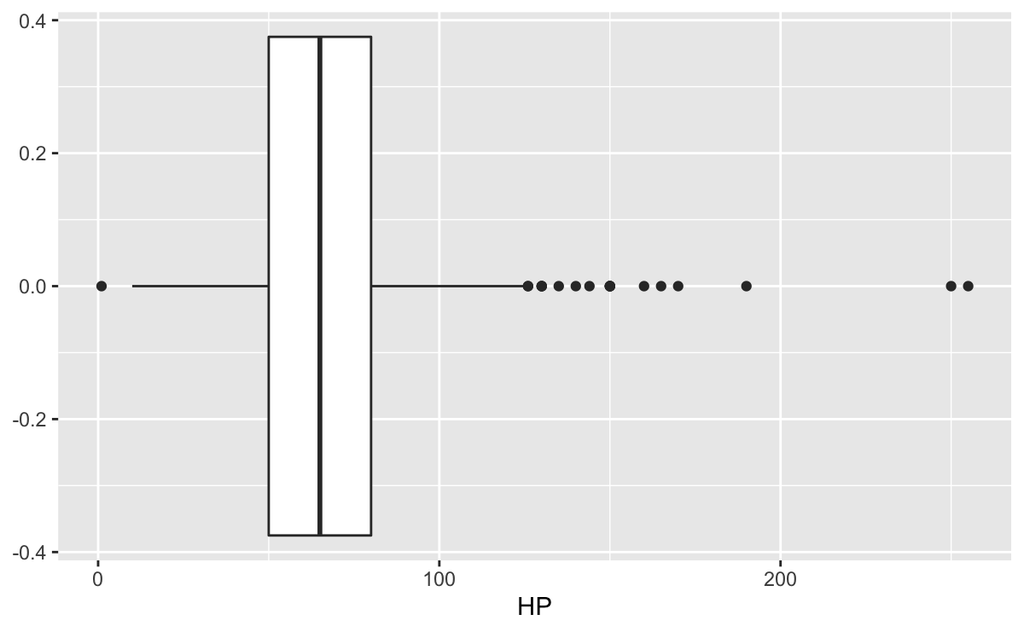

```r
# basic plots
ggplot(data=pokemon_data)+
  geom_boxplot (mapping = aes(x=HP))
```

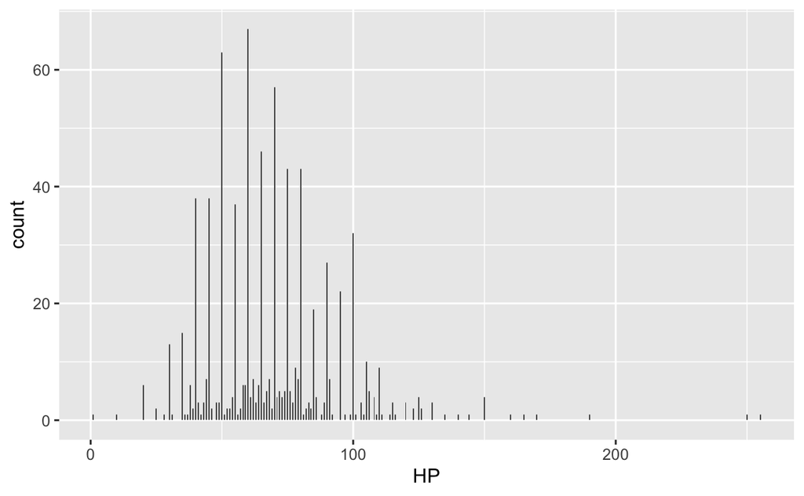

```r
ggplot(data = pokemon_data) +
  geom_histogram(mapping = aes(x = HP), binwidth = 0.5)
```

```r
# Obtaining a correlation matrix for columns that are numeric and represent a pokemon combat statistic
pokemon_data_numeric <- select(pokemon_data, Total, HP, Attack, Defense, SpAtk, SpDef,Speed)
res <- cor(pokemon_data_numeric)
round(res,2)
```

```
        Total   HP Attack Defense SpAtk SpDef Speed
Total    1.00 0.62   0.74    0.61  0.75  0.72  0.58
HP       0.62 1.00   0.42    0.24  0.36  0.38  0.18
Attack   0.74 0.42   1.00    0.44  0.40  0.26  0.38
Defense  0.61 0.24   0.44    1.00  0.22  0.51  0.02
SpAtk    0.75 0.36   0.40    0.22  1.00  0.51  0.47
SpDef    0.72 0.38   0.26    0.51  0.51  1.00  0.26
Speed    0.58 0.18   0.38    0.02  0.47  0.26  1.00
```

```r
# Obtaining our model with HP as the quantitative response variable and Attack and Sp..Def as
# quantitative explanatory variables, since Attack and Sp..Def are most highly correlated with HP #according to our correlation matrix.

model <- lm(HP ~ Attack + SpDef, data = pokemon_data)
summary(model)
```

```
Call:
lm(formula = HP ~ Attack + SpDef, data = pokemon_data)

Residuals:
    Min      1Q  Median      3Q     Max
-72.113 -12.439  -2.847   7.803 192.194

Coefficients:
            Estimate Std. Error t value Pr(>|t|)
(Intercept) 28.76962    2.58587  11.126   <2e-16 ***
Attack       0.27264    0.02493  10.934   <2e-16 ***
SpDef        0.26355    0.02908   9.062   <2e-16 ***
---
Signif. codes:  0 ‘***’ 0.001 ‘**’ 0.01 ‘*’ 0.05 ‘.’ 0.1 ‘ ’ 1

Residual standard error: 22.07 on 797 degrees of freedom
Multiple R-squared:  0.2552,    Adjusted R-squared:  0.2533
F-statistic: 136.5 on 2 and 797 DF,  p-value: < 2.2e-16
```

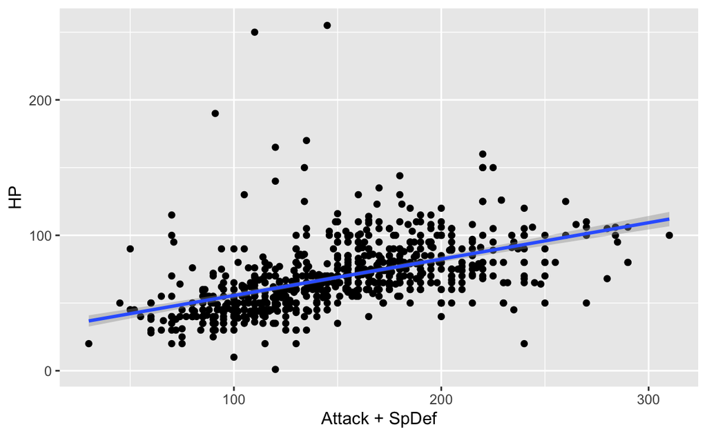

```r
# showing variability
ggplot(data = pokemon_data, aes(x =Attack + SpDef, y = HP), na.rm= TRUE) +
  geom_point()+
  geom_smooth(method='lm')
```

We are trying to observe a linear relationship between these two variables and HP. Several conditions must be met for our multiple linear regression model to be usable, linearity (each variable being linearly related to the outcome), independence of residuals, residuals that are nearly normal, and equal variability among residuals. By observing our correlation matrix, we can see that the two explanatory variables that we have chosen come close but still do not seem to have a linear relationship with our response variable, violating our first condition. Our third condition of normality of residuals is clearly violated when observing the upper right portion of the QQ plot. Our fourth condition of constant variance appears to be violated as well, which we can see in the graph which plots our residuals against our predicted values.

For our data, we will state our null hypothesis as there being no linear relationship between the response variable of HP and the two quantitative variables of Attack and SpDef. Our alternative hypothesis being that there exists some linear relationship between the two explanatory variables of Attack and SpDef and our response variable of HP.

After obtaining our regression model, we can see that the test statistic for our Attack coefficient is 10.934 with a p-value <2e-16. Our test statistic for the SpDef coefficient is 9.062 while our p-value is <2e-16. Seeing that both of our coefficients are demonstrating extreme statistical significance it would be sensible to reject our null hypothesis. However, it is important to note that this model has an adjusted R-squared of .2533, meaning that approximately 25% of the variation in our response variable can be explained by our explanatory variables. All being said, this model has its limitations and should not be used as a predictive model. It failed to meet nearly all of the conditions, by referring to the outlier test ran in R, there are a few observable outliers in our data, and it also has a demonstrated adjusted R-squared that is well outside of an acceptable range.

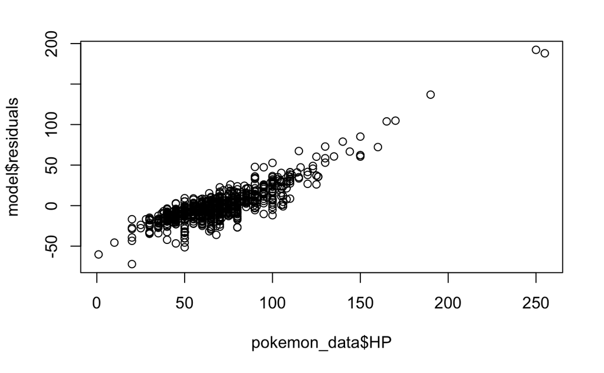

```r
#Residual plots - linearity & variance
plot(model$residuals ~ pokemon_data$HP + pokemon_data$SpDef)
```

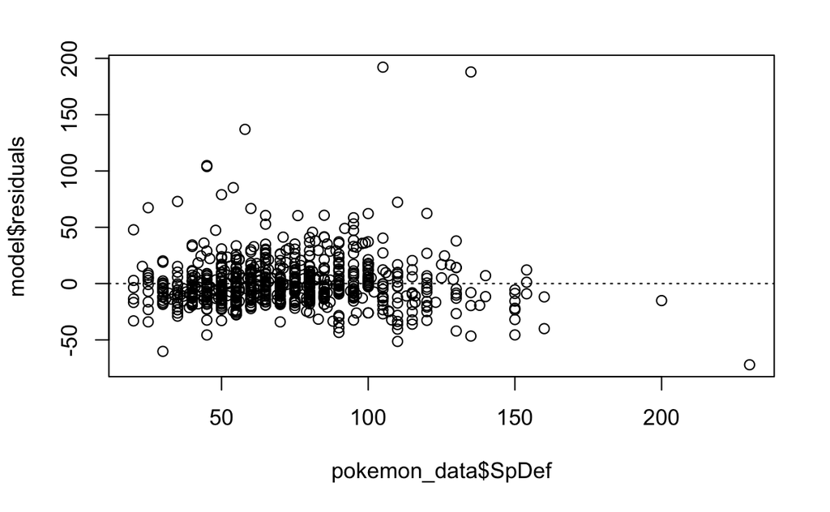

```r
abline(h = 0, lty = 3)  # adds a horizontal dashed line at y = 0
```

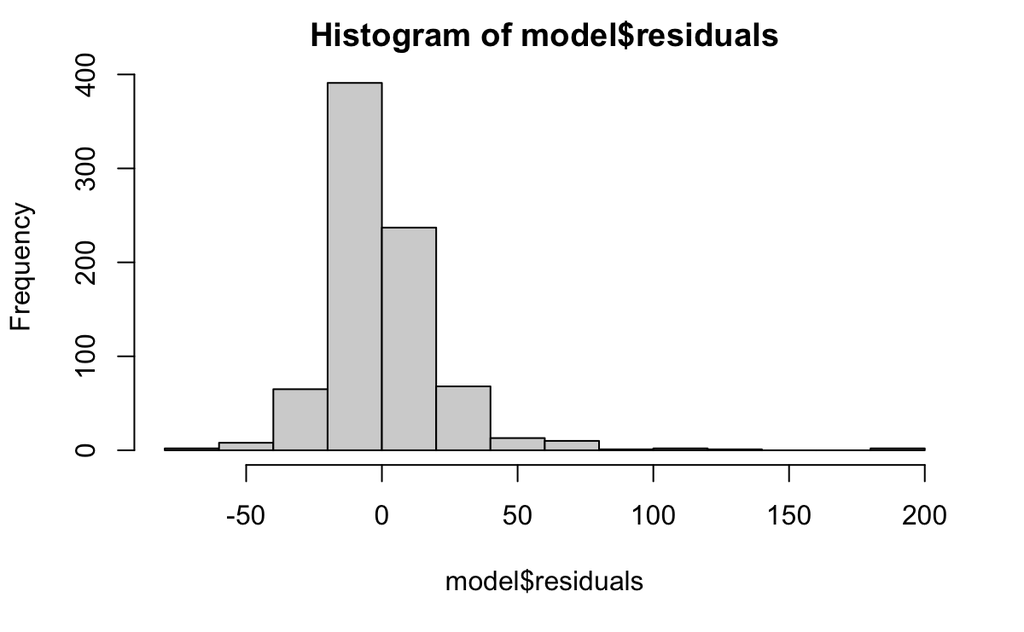

```r
#Residual plots - normality (1)

hist(model$residuals)
```

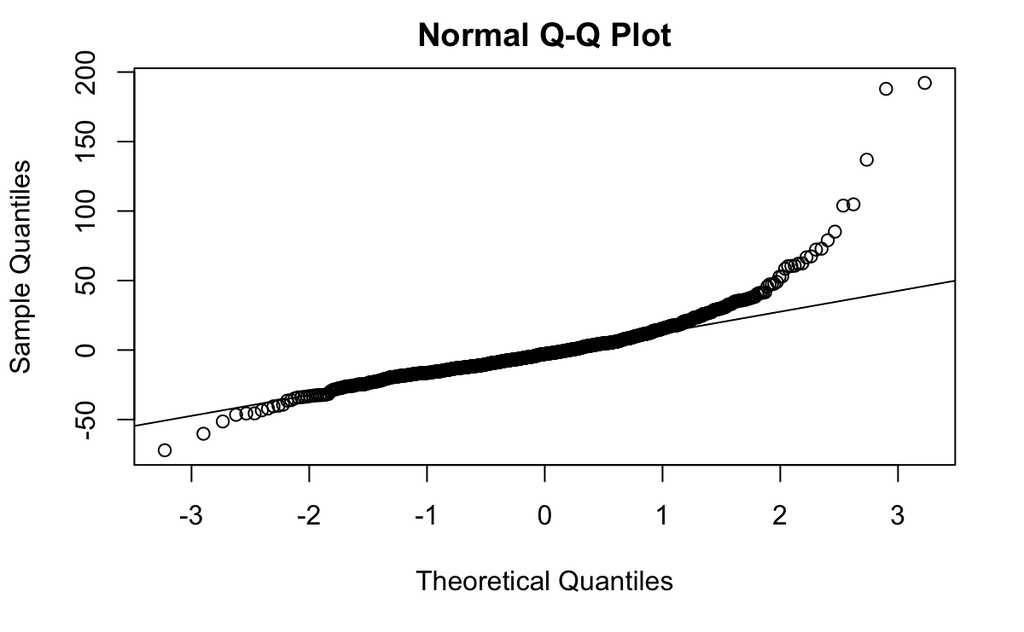

```r
#Residual plots - normality (2)
qqnorm(model$residuals)
qqline(model$residuals)  # adds diagonal line to the normal prob plot
```

```r
# Checking the model fit diagnostics:  individual p-values, adjusted R-squared and F statistic.
summary(model)
```

```
Call:
lm(formula = HP ~ Attack + SpDef, data = pokemon_data)

Residuals:
    Min      1Q  Median      3Q     Max
-72.113 -12.439  -2.847   7.803 192.194

Coefficients:
            Estimate Std. Error t value Pr(>|t|)
(Intercept) 28.76962    2.58587  11.126   <2e-16 ***
Attack       0.27264    0.02493  10.934   <2e-16 ***
SpDef        0.26355    0.02908   9.062   <2e-16 ***
---
Signif. codes:  0 ‘***’ 0.001 ‘**’ 0.01 ‘*’ 0.05 ‘.’ 0.1 ‘ ’ 1

Residual standard error: 22.07 on 797 degrees of freedom
Multiple R-squared:  0.2552,    Adjusted R-squared:  0.2533
F-statistic: 136.5 on 2 and 797 DF,  p-value: < 2.2e-16
```

```r
# Also checking residual square error
RSE_hab <- sigma(model)/mean(pokemon_data$HP)
RSE_hab
```

```
[1] 0.3185891
```

```r
# Additional diagnostics

anova(model)
```

```
Analysis of Variance Table

Response: HP
           Df Sum Sq Mean Sq F value    Pr(>F)
Attack      1  92945   92945 190.904 < 2.2e-16 ***
SpDef       1  39985   39985  82.126 < 2.2e-16 ***
Residuals 797 388034     487
---
Signif. codes:  0 ‘***’ 0.001 ‘**’ 0.01 ‘*’ 0.05 ‘.’ 0.1 ‘ ’ 1
```

```r
outlierTest(model) #Bonferonni "p-value for most extreme obs
```

|  | rstudent | unadjusted p-value | Bonferroni p |
| --- | --- | --- | --- |
| 122 | 9.213012 | 2.7609e-19 | 2.2087e-16 |
| 262 | 9.015487 | 1.4366e-18 | 1.1493e-15 |
| 218 | 6.370856 | 3.1778e-10 | 2.5423e-07 |
| 352 | 4.823975 | 1.6865e-06 | 1.3492e-03 |
| 656 | 4.779764 | 2.0902e-06 | 1.6721e-03 |

```
[1] 122 262
```

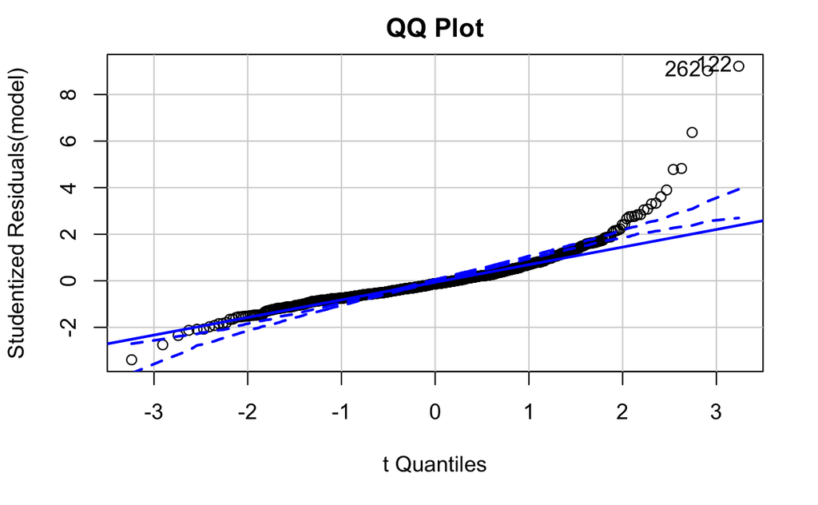

```r
qqPlot(model, main = "QQ Plot" ) #qq plot for studentized resid
```

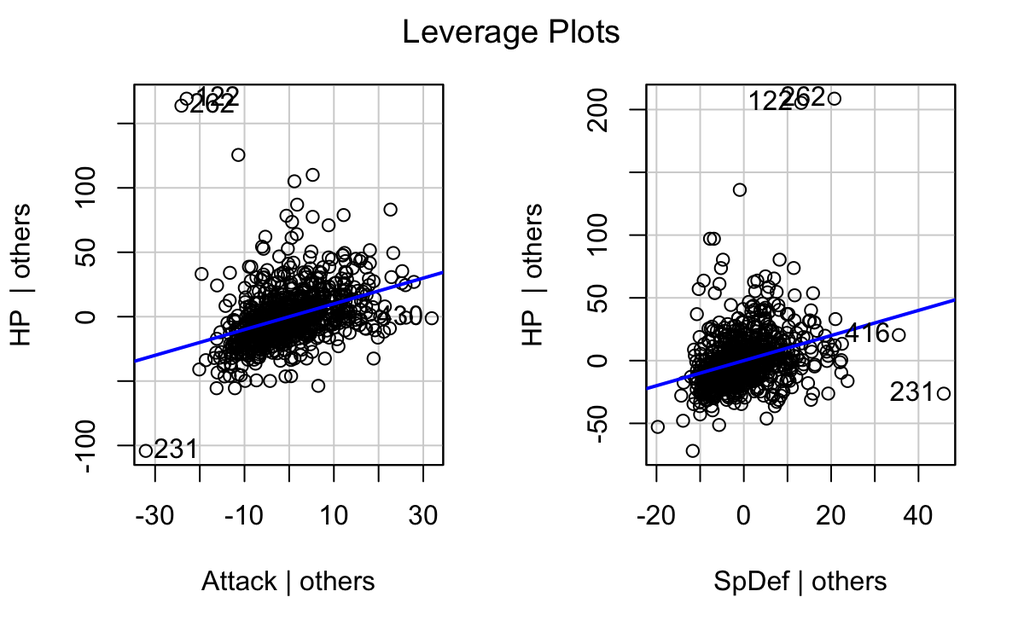

```r
leveragePlots(model) #leverage plots
```

## Recommendations

Upon constructing a linear multiple regression model with HP as our response variable and Attack/SpDef as our explanatory variables, it became apparent that these two explanatory variables are extremely statistically significant (highly unlikely to be due to chance) in terms of being valid predictors of our response variable. However, the model which included these predictors violated several of the necessary conditions for our model to be considered a good predictive method. Only a small (~25%) amount of the variation in our response variable could be explained by our explanatory variables. This offers us new insight into observing a possible linear relationship between Attack/SpDef and HP, but there needs to be work done, perhaps via transformation of the regression, to have a model that can be effectively used as a predictor of total HP.

After creating a linear regression model with SpAtk as the explanatory model and HP as the response variable, I was able to determine that the statistics for my variables (SpAtk and HP) are significant in relation to determining an association between the predictor (SpAtk) and the outcome variables (HP). Although the linear regression model failed to meet the normality condition, the predictor and response variable was able to show valid results (meeting the conditions) for Homoscedasticity, Independence, and Linearity. In my findings, I came across a couple of limitations, which are the outliers from the regression line (based on HP and SpAtk) and the unmet normality condition for the linear regression model. With that said, this provides us a new insight in using different variables that are better matched for the linear model conditions or using non-linear transformations of the predictors in the regression model (log, square root, etc) to avoid possible fitted patterns in linearity and homogeneity of variance.

## Reflections

Throughout the semester, the Unit Projects assigned to us have greatly expanded our knowledge in statistical coding and provided us opportunities to apply what we learned in the course to actual data. With the chance to examine data in individual ways, we were able to collaborate and understand each other’s results. This method also provided an opportunity to examine an entire data set, in which we were able to fairly distribute a specific analysis to each other for every new project. We were always able to undergo an in-depth experience with our personally assigned analyses and learn new techniques to use in our data analysis. Furthermore, these projects improved us as individuals to be able to handle more complex data organization, collection, interpretation, and presentation in the future.

Moving forward, our group learned how statistical representations look when real life data is put into it. Using a set of data that is made to highlight particular aspects of a statistical analysis means that the concept is easy to identify, but real data won’t always be simple to work with and understand. Additionally, learning to clean up data so that it can be used in statistical analysis is a helpful skill to have learned about with these projects. We also learned about how our individual analyses relate to other analyses when we deal with both quantitative and qualitative variables.

Through the 3 unit projects, we learned how to do different types of analysis and inferential testing on R, as well as how certain functions work. We were able to apply the skills we learned in class to the projects, which made us understand the concepts better and how we would apply those skills to real life. We learned how to write a briefing memo, incorporating word analysis as well as coding, using R. We also learned how to collaborate as a team and decided what methods worked best with our team, in order to complete the projects efficiently. Additionally, we learned how to deal with situations that were unfavorable for us and how to make sure that those didn’t affect our group projects in the end.

The main challenges we faced when it came to completing the unit projects dealt with coordinating our team efforts as a result of: losing members of our team, health complications among members, and the balancing of other classwork. We managed to overcome these challenges by maintaining an organized schedule for meeting times and being certain to give clear direction on the division of group work, including the enactment of deadlines for group work. Other challenges came with the analyses, due to the data set we selected. Other data sets may have had more concrete relationships between data, but Pokemon stats rarely seemed to have observable patterns that we could effectively capture, likely due to the nature of each Pokemon being created with specific and unique intents. Nonetheless, by staying in close contact with the instructor and TA’s, we were able to get clarification on our many questions about how to conduct our analyses and deal with our data set, and were able to complete the projects to the best of our ability. As a whole, having unforeseen circumstances get in the way of the team and dealing with a data set that proved surprisingly challenging allowed us to not only gain more experience with functioning in a team environment despite setbacks, but allowed us to conduct statistical analyses on real-world data. We are certain these skills will prove incredibly useful in our future career paths.